# AN588-Week-3-PeerCommentary

Nicole

2023-10-01

## Peer Commentary

1. *What you learned from running their Original Homework Code that helped* *improve your own code:* I did pretty much all of the questions exactly the same as you but one thing I really I noticed in your histogram was the sequence for the breaks (0 to 30 by1) made a lot of sense and looked nice on the plot. I just did c(0:30) and it does look basically the same but knowing that yours is going up by 1 feels extra secure!
2. *What you did in your own code that might help to improve theirs:* I noticed you did not have a picture of a titi monkey formatted at the top. I found a way to include an image in a code chunk. It looks like this: {r titimonkey, echo=FALSE, fig.align=‘center’, fig.cap=‘[caption]’, out.width=‘25%’} knitr::include_graphics(‘~/[file path]’). And you put that inside a chunk with the ``` on top and bottom. You could also try using HTML code in the markdown text parts.
3. *What challenges, if any, you both faced in your code that could not be* *helped by comparison:* I’m not sure you faced any challenges but I saw your note at the bottom about the histogram and the random numbers being generated. I am not sure if there is an established way to ‘save’ the random numbers once generated but you could run SimResult, copy and paste the results to a new vector, then use that as the data in the histogram. It’s a little round a bout but gets at what you’re asking.
4. *Whether the annotation/commenting on your peer’s Original Homework Code is* *readable and interpretable to you, and if not then how it could be improved:* Your headers, text, and chunks are very readable! It’s super easy to navigate. You might improved with named chunks in case you run into issues with knitting, but most of my knitting issues are from accidentally naming two chunks the same name so take that advice with a grain of salt! A table of contents might also be helpful. That goes into the YAML with toc: true in the output.

## Question 1

What is the probablity that she will hear more than 8 calls during any given session?

```r
l <- 15
Pr8 <- ppois(8, l, lower.tail = FALSE)
Pr8
```

```
## [1] 0.9625535
```

Question 1 complete :)

## Question 2

What is the probablity that she will hear no calls in a session?

```r
Pr0 <- ((l^0)*exp(-l))/(factorial(0))
Pr0
```

```
## [1] 3.059023e-07
```

Question 2 complete :)

## Question 3

What is the probability that she will hear exactly 3 calls in a session?

```r
Pr3 <- ((l^3)*exp(-l))/(factorial(3))
Pr3
```

```
## [1] 0.0001720701
```

Question 3 complete :)

## Question 4

Plot the relevant Poisson mass function over the values in range 0 ≤ x ≤ 30.

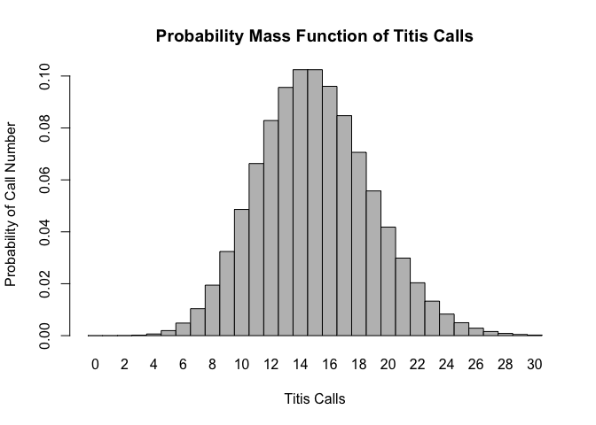

```r
x <- 0:30
CallPr <- dpois(x=x, lambda=l)
barplot(CallPr, names.arg=x, space=0, xlab="Titis Calls", ylab="Probability of Call Number", main="Probability Mass Function of Titis Calls")
```

Question 4 complete :)

## Question 5

Simulate 104 results from this distribution (i.e., 2 years of Saturday monitoring sessions).

```r
nSat <- 104
SimResult <- rpois(nSat, l)
SimResult
```

```
##   [1] 16 13 17 13 15 17 17 10 19 19 23 20 12 23 11  8 17 14 15 17 10 16 14 12 18
##  [26] 10 13 17 13 18 12  8 16 11  7 21 14 16 12 12 18 15 15 20 24 21 14 18 10 22
##  [51] 18 19 14 18 17 15 16 16 18 10 11 15 13 16 19 12 20 17 24 11 20 13 16  8 15
##  [76] 13 17 13 15 19 21 13 20 10 11 14 17  9 20 15 19 21 19 10 16 10 18 13 16  9
## [101] 11 10 15 11
```

Question 5 complete :)

## Question 6

Plot the simulated results using hist() and use xlim() to set the horizontal limits to be from 0 to 30. How does your histogram compare to the shape of the probability mass function you plotted above?

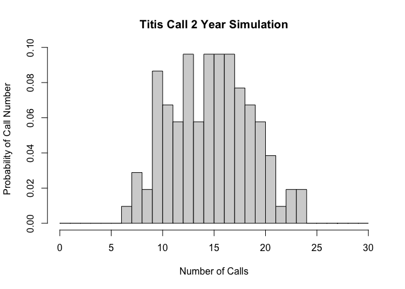

```r
hist(SimResult, breaks=seq(from=0, to=30, by=1), probability=TRUE, main="Titis Call 2 Year Simulation", xlab="Number of Calls", ylab = "Probability of Call Number", xlim=c(0,30))
```

**Note:** I noticed that the hist() plot changes every time the Rmd file is knitted as Question 5 produces different simulation results. Is there a way or is it necessary to make the simulation result fixed?

Anyway, question 6 complete :)

Homework 2 complete :D